# Regression Modelling

# Warm-up: The Data

## 1.1 What are we working with?

This session uses **simulated data based on a subset of variables from the [STOP-HCV consortium](https://www.expmedndm.ox.ac.uk/research/stop-hcv)**, a UK-based study of Hepatitis C virus (HCV) infection. The data have been simulated for teaching purposes and do not represent actual study participants.

HCV (Hepatitis C Virus) is a leading cause of chronic liver disease worldwide.

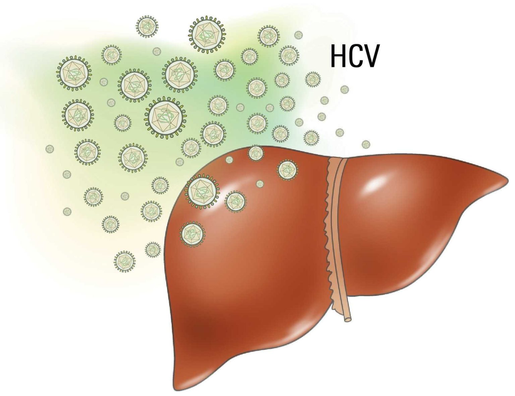

```r
hcv_dataset <- readRDS("hcv_dataset.rds")
```

The dataset is a list with three parts: `phenotype` (the outcomes), `HLA` (the genotypes) and `covariate` (patient characteristics).

```r
names(hcv_dataset)[1:3]
```

```
## [1] "HLA"       "phenotype" "covariate"
```

### Phenotypes

- **Viral load** is measured on a continuous scale (log10 IU/mL).
- **Cirrhosis** is binary (yes/no).
- **Fibrosis** is a continuous liver fibrosis score (simulated, arbitrary units). We will use it in the causal thinking session.

```r
pheno <- hcv_dataset$phenotype
head(pheno)
```

```
##   cirrhosis viral_load fibrosis
## 1        No      6.763    6.221
## 2        No      4.983    5.647
## 3        No      4.618    4.193
## 4       Yes      5.682    6.164
## 5        No      6.306    5.561
## 6        No      5.573    6.236
```

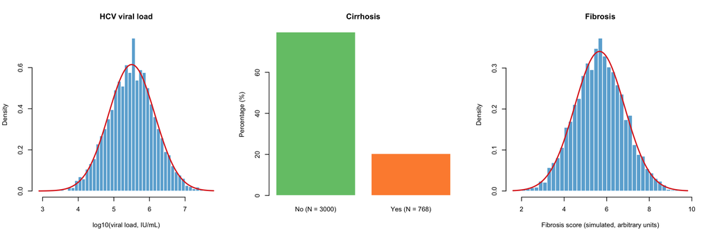

**Note:** Because the raw viral load values span several orders of magnitude, we work with `log10(viral load)` throughout, which brings the distribution close to normal (red curve) and makes regression coefficients interpretable.

### Genetics

HLA (Human Leukocyte Antigen) is a highly polymorphic gene complex on chromosome 6 that plays a central role in immune recognition. Two properties of HLA are particularly important for this session:

- **High polymorphism** — there are hundreds of alleles at each locus, meaning individuals differ substantially in their HLA genotype.
- **Linkage disequilibrium (LD)** — alleles at different HLA loci tend to co-occur more often than expected by chance.

*(You can read [Shiina et al. (2009)](https://www.nature.com/articles/jhg20085) for a more detailed overview of HLA genetics if you are interested.)*

Each allele is coded as the number of copies a patient carries (0, 1 or 2). The first column is the sample ID.

```r
hla <- hcv_dataset$HLA
hla[1:5, 1:6]
```

```
##            ID HLA_A.02.01 HLA_A.03.01 HLA_A.11.01 HLA_A.24.02 HLA_C.03.04
## 1 Sample_2193           0           0           0           0           0
## 2 Sample_1372           0           0           0           0           0
## 3 Sample_1985           0           1           0           0           0
## 4  Sample_878           1           1           0           0           0
## 5 Sample_2003           2           0           0           0           0
```

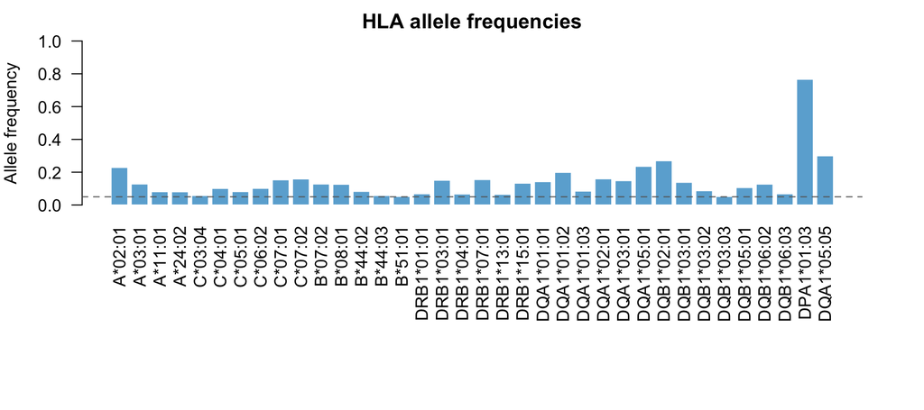

This dataset includes 36 common HLA alleles, each with a frequency greater than 5% (dashed line) in the study population.

### Cohort characteristics

In addition to HLA genotypes, we have five patient characteristics: age, sex, BMI, genetic ancestry (two populations, coded 0/1) and ALT (alanine aminotransferase, a blood marker of liver inflammation, IU/L).

```r
covar <- hcv_dataset$covariate
head(covar)
```

```
##   AGE    SEX  BMI ANCESTRY  ALT
## 1  62 Female 29.2        0 50.1
## 2  41 Female 26.1        1 45.2
## 3  58 Female 22.1        0 30.1
## 4  65 Female 31.7        0 39.7
## 5  54   Male 24.7        0 32.3
## 6  45 Female 26.7        1 47.9
```

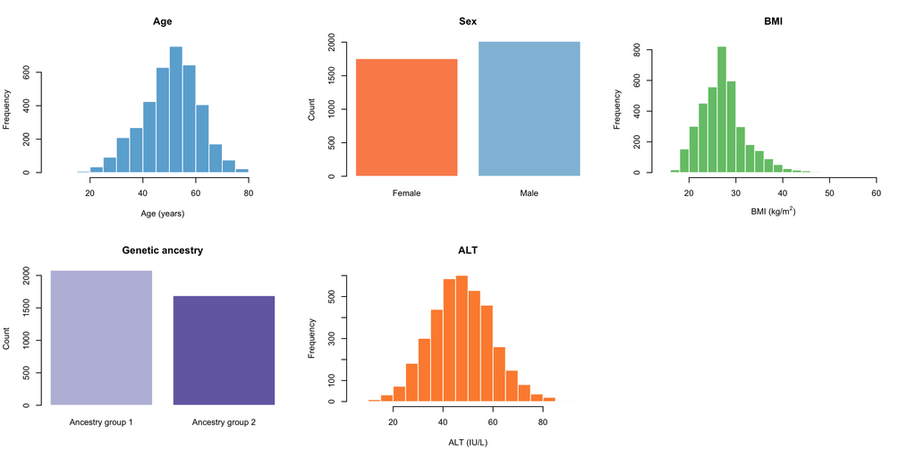

Given prior epidemiological evidence that age, sex, and BMI are associated with HCV outcomes, we will treat these as covariates throughout our analyses. Ancestry and ALT play a special role, which we will come back to in the causal thinking session: adding a variable to a model is not always harmless.

Note that a few patients have missing age or BMI:

```r
colSums(is.na(covar))
```

```
##      AGE      SEX      BMI ANCESTRY      ALT
##       21        0       21        0        0
```

# 1.2 Checklist: what we will learn

In this course we will learn how to analyse data like these with regression:

1. **Linear regression**: model a *continuous* outcome such as viral load, and interpret the effect of each HLA allele copy.
2. **Logistic regression**: model a *binary* outcome such as cirrhosis (yes/no), and interpret effects as odds ratios.
3. **Regularised regression**: fit many correlated HLA alleles *jointly*, using a penalty to tell which allele is really driving a signal.
4. **Causal thinking**: use directed acyclic graphs (DAGs) to decide *which variables to adjust for*, and which ones to leave out (confounders, mediators and colliders).